# Sensibilitat de l’índex LPI-Cat a tendències poblacionals extremes

Tractament de dades i avalució dels efectes de la distribució i la cobertura sobre les tendències i la seva incertesa

Marc Anton

2026-01-02

# 1. Introucció

Aquest *markdown* conté el pipeline per fer la lectura de les dades necessaries per els primers anàlisi del Treball de Final de Màster **Sensibilitat de l’índex LPI-Cat a tendències poblacionals extremes** de Marc Anton Recasens.

En concret el pipeline té dues fases:

1. Càrrega de dades i tractament per a generar un *input file* per a l’anàlisi
2. Avalució dels efectes de la distribució i la cbertura del mostratge en la tendència i la seva incertesa

# 2. Càrrega de dades

Cal tenir en compte que les dades estan en diversos formats:

1. Les distribucions venen de fitxers zip que comencen per Cartobio
2. Els iItineraris i comptatges venen de zips que comencen per la data que s’ha baixat
3. Les tendències venen totes junts amb un sol fitxer

Comencem amb el fitxer de tendències que és un de sol i ja baixa amb el que necessitem. Addicionalment hi he posat el tàxon a ma

```r
trends <- read.csv("./lpi_cat2024_species_trends_metadata.csv", header = TRUE, sep = ";")
```

Ara, anem amb les distribucions i els itineraris

```r
## Fem una llista dels zips

zips <- list.files(, pattern = "\\.zip$", full.names = TRUE)

## Els llegim un a un i anem posant les dades en els fitxers. Tenim 2 tipus de zips
##    i els tractem per separat

prefix <- "./cartobio"
sites <- data.frame()
counts <- data.frame()
distributions <- data.frame()
for (i in 1:length(zips)) {
  print(i)
  zip_file <- zips[i]
  print(zip_file)

  if (grepl(paste0("^", prefix), zip_file) == TRUE) {
    print("dist")
    fitxer <- unzip(zip_file, list = TRUE)
    distributions <- rbind(distributions,
                     read.csv(unz(zip_file,fitxer$Name), header = TRUE, sep = ";"))
  }
  else {
    print ("surveys")
    #
    #  Abans que res, com que hi ha codis de sites iguals en diferents projectes,
    #     extraiem el nom del projecte
    #
    projecte <- tail(strsplit(zip_file, "_")[[1]],1)
    projecte <- sub("\\.zip$", "", projecte)
    print(projecte)

    #
    #  Ara carreguem els sites
    #
    site <- read.csv(unz(zip_file, "sites.csv"), header = TRUE, sep = ";")
    site$projecte <- projecte
    sites <- rbind(sites, site)
    head(sites)

    #
    # I els counts
    #
    count <- read.csv(unz(zip_file, "counts.csv"), header = TRUE, sep = ";")
    count$projecte <- projecte
    counts <- rbind(counts, count)
    head(counts)
  }
}
```

```
## [1] 1
## [1] "./2025-10-24_lpi_site_level_amfibis.zip"
## [1] "surveys"
## [1] "amfibis"
## [1] 2
## [1] "./2025-10-24_lpi_site_level_cbms.zip"
## [1] "surveys"
## [1] "cbms"
## [1] 3
## [1] "./2025-10-24_lpi_site_level_farmdindis.zip"
## [1] "surveys"
## [1] "farmdindis"
## [1] 4
## [1] "./2025-10-24_lpi_site_level_liro.zip"
## [1] "surveys"
```

[output cut: 61 more lines]

```r
# El fitxer de distribucions, porta algun valor duplicat que ens pot donar problemes i, per tant, l'eliminem
distributions <- distributions[,1:2]
distributions <- distinct(distributions)
```

# 3. Generació de l’*input file*

En la distribució, sabem que, a vegades, hi ha quadrats UTM 10km que no estan a la distribució, però que apareixen en el mostratges. Començem, per tant, afegint aquests quadrats

```r
#   Agafem les espècies i els quadrats en els que hi ha cens

species_sites <- inner_join(sites, counts, by = c("code", "projecte")) %>%
  dplyr::select(species, X10x10) %>% distinct()

#   Igualem el noms de columnes a distributions i a species_sites per poder fer joins

names(distributions)[names(distributions) == "scientific_name"] <- "species_name"
names(species_sites)[names(species_sites) == "species"] <- "species_name"
names(species_sites)[names(species_sites) == "X10x10"] <- "cellcode"

#   Per treballar be, però, farem el dataset de sortida només per aquelles espècies
#      per a les quals tenim distribució, evitant NAs
#  Comencem per saber quines espècies estan a distribution

speciesDist <- unique(distributions$species_name)

#   Filtrem els sites pe aquestes espècies

species_sites <- species_sites %>% filter(species_name %in% speciesDist)

#  I afegim els quadrats en els quals hi ha mostreig a distributions

NewUTM10 <- anti_join(species_sites, distributions, by = c("species_name","cellcode"))

distributions <- bind_rows(distributions, NewUTM10)
```

Ara ja podem generar la variable distribució com a el total de quadrats UTM10km en els que està l’espècie.

```r
distributions_n <- distributions %>%
  group_by(species_name) %>%   # Agrupa per espècie
  summarise(n = n())              # Comptar files (que són les UTM10) per espècie

distributions_n
```

```
## # A tibble: 540 × 2
##    species_name                  n
##    <chr>                     <int>
##  1 Accipiter gentilis          305
##  2 Accipiter nisus             310
##  3 Achondrostoma arcasii         5
##  4 Acridotheres tristis          1
##  5 Acrocephalus arundinaceus   173
##  6 Acrocephalus melanopogon     13
##  7 Acrocephalus scirpaceus     154
##  8 Actitis hypoleucos           43
##  9 Aegithalos caudatus         358
## 10 Aegolius funereus            34
## # ℹ 530 more rows
```

```r
# La incorporem al fitxer d'entrada a les anàlisi

inputDf <- left_join(trends, distributions_n, by = "species_name")
```

Ara generem la cobertura com el percentatge d’UTM10km en els quals es troba l’espècie en els mostratges dins la distribució de l’espècie

```r
#  Generem la cobertura fent el percentatge

coverage <- species_sites %>%
  group_by(species_name) %>%
  summarise(n_UTM10 = n_distinct(cellcode))
coveragePerc <- left_join(distributions_n, coverage, by = "species_name")
coveragePerc$percentage <- (coveragePerc$n_UTM10 / coveragePerc$n) * 100
print(coveragePerc)
```

```
## # A tibble: 540 × 4
##    species_name                  n n_UTM10 percentage
##    <chr>                     <int>   <int>      <dbl>
##  1 Accipiter gentilis          305     131      43.0
##  2 Accipiter nisus             310     165      53.2
##  3 Achondrostoma arcasii         5       2      40
##  4 Acridotheres tristis          1      NA      NA
##  5 Acrocephalus arundinaceus   173      60      34.7
##  6 Acrocephalus melanopogon     13       7      53.8
##  7 Acrocephalus scirpaceus     154      64      41.6
##  8 Actitis hypoleucos           43      10      23.3
##  9 Aegithalos caudatus         358     244      68.2
## 10 Aegolius funereus            34       3       8.82
## # ℹ 530 more rows
```

```r
# I l 'annexem al inputDf

inputDf <- inputDf %>%
  left_join(coveragePerc %>%
              dplyr::select(species_name, percentage), by = "species_name")
```

Finalment, arreglem el *input file* amb uns noms més explícits en relació al que estudiem

```r
inputDf <- inputDf[,c("species_code", "species_name", "Taxononmic_group",
                 "annual_change_percentage", "std_error", "n", "percentage")]
colnames(inputDf) <- c("SpeciesCode", "SpeciesName", "Taxon", "Trend", "SETrend",
                       "Distribution", "SamplingCoverage")

#     Mirem com  son els camps

summary(inputDf)
```

```
##   SpeciesCode       SpeciesName           Taxon               Trend
##  Min.   :   52477   Length:353         Length:353         Min.   :-21.790
##  1st Qu.:   58410   Class :character   Class :character   1st Qu.: -3.535
##  Median : 1919712   Mode  :character   Mode  :character   Median : -1.299
##  Mean   : 2597410                                         Mean   : -1.234
##  3rd Qu.: 5137903                                         3rd Qu.:  1.090
##  Max.   :10000125                                         Max.   : 25.408
##
##     SETrend         Distribution   SamplingCoverage
##  Min.   : 0.1246   Min.   :  5.0   Min.   :  2.609
##  1st Qu.: 0.3997   1st Qu.: 83.0   1st Qu.: 36.467
##  Median : 0.7918   Median :173.0   Median : 44.156
##  Mean   : 1.2824   Mean   :187.4   Mean   : 45.243
##  3rd Qu.: 1.3568   3rd Qu.:299.0   3rd Qu.: 54.801
##  Max.   :29.0091   Max.   :378.0   Max.   :100.000
##                    NA's   :16      NA's   :18
```

Com que tenim molts NAs i volem limitar l’anàlisi a la disponibilitat de dades, eliminem els registres que no tenen distribució o cobertura

```r
inputDf <- inputDf[is.na(inputDf$Distribution) == FALSE,]
inputDf <- inputDf[is.na(inputDf$SamplingCoverage) == FALSE,]
summary(inputDf)
```

```
##   SpeciesCode      SpeciesName           Taxon               Trend
##  Min.   :  52477   Length:335         Length:335         Min.   :-21.790
##  1st Qu.:  58236   Class :character   Class :character   1st Qu.: -3.553
##  Median :1911461   Mode  :character   Mode  :character   Median : -1.299
##  Mean   :2536270                                         Mean   : -1.303
##  3rd Qu.:5136562                                         3rd Qu.:  1.029
##  Max.   :9796816                                         Max.   : 25.408
##     SETrend         Distribution   SamplingCoverage
##  Min.   : 0.1246   Min.   :  5.0   Min.   :  2.609
##  1st Qu.: 0.3964   1st Qu.: 83.0   1st Qu.: 36.467
##  Median : 0.7507   Median :173.0   Median : 44.156
##  Mean   : 1.2700   Mean   :187.4   Mean   : 45.243
##  3rd Qu.: 1.3412   3rd Qu.:298.5   3rd Qu.: 54.801
##  Max.   :29.0091   Max.   :378.0   Max.   :100.000
```

Ara sí!!

Mirem quina pinta fan les dades per grup taxonòmic. Primer quantes espècies tenim

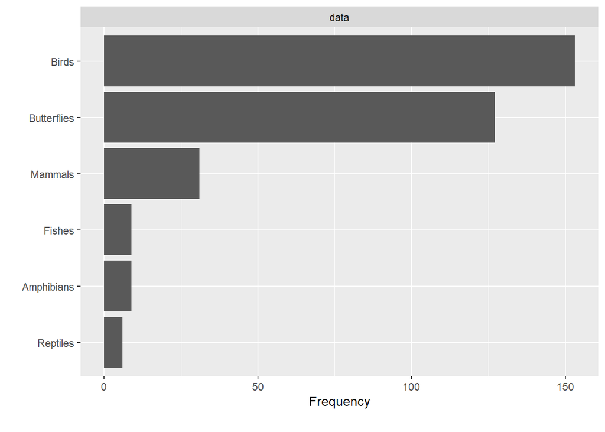

```r
taula_taxon <- inputDf %>%
  group_by(Taxon) %>%
  summarise(num_especies = n_distinct(SpeciesCode)) %>%
  arrange(desc(num_especies))
plot_bar(inputDf$Taxon)
```

I després, la dispersió de les variables

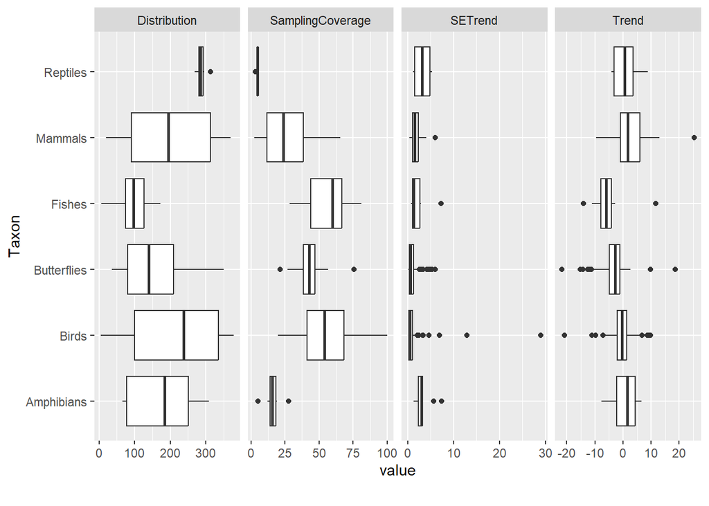

```r
plot_boxplot(inputDf[,c(3:ncol(inputDf))], by = "Taxon")
```

Fem també un summarytools per veure millor les variables que ens interessen

```r
inputDfSummarytools <- bind_cols((inputDf[,3:4]),
                                 abtsTrend = abs(inputDf$Trend),
                                 (inputDf[,5:7]))
dfSummary(inputDfSummarytools) %>% stview()
```

```
## Switching method to 'browser'
```

```
## Output file written: C:\Users\marca\AppData\Local\Temp\RtmpEvWyoS\file4e145d5f6a91.html
```

# 4. Anàlisi de correlació entre tendències i errors estandards amb distribució i cobertura

Abans de començar amb l’anàlisi, ens cal comprovar la normalitat de les variables resposta a analitzar. Les variables són: 1) la tendència, i 2) el seu error estàndard

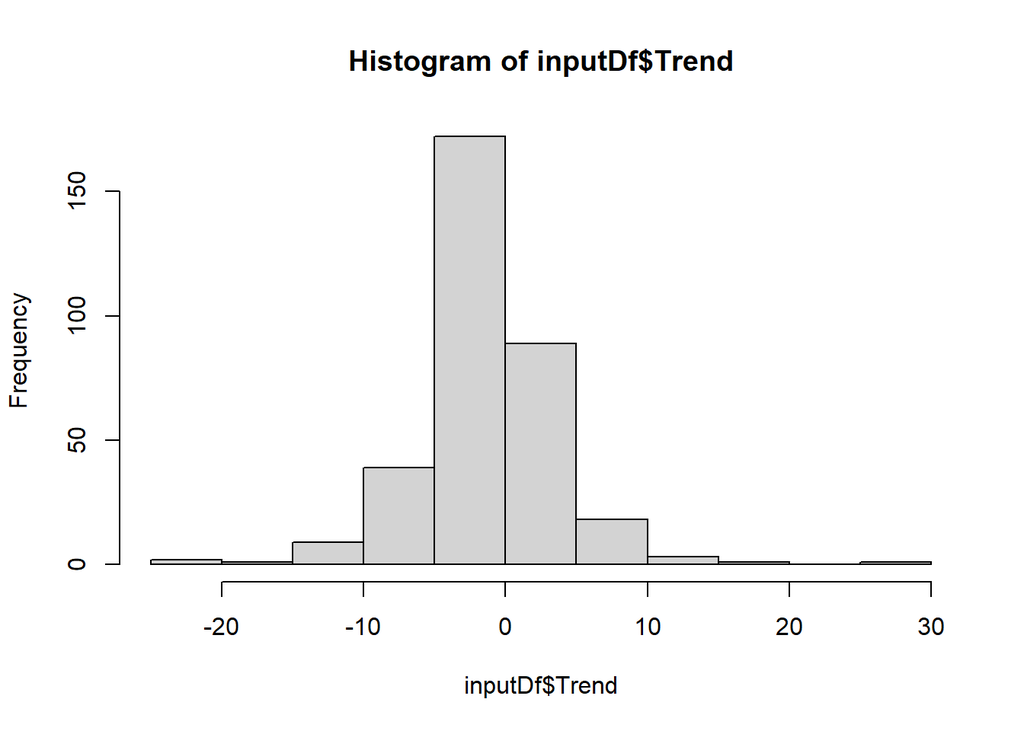

```r
#  Per la tendència

hist(inputDf$Trend)
```

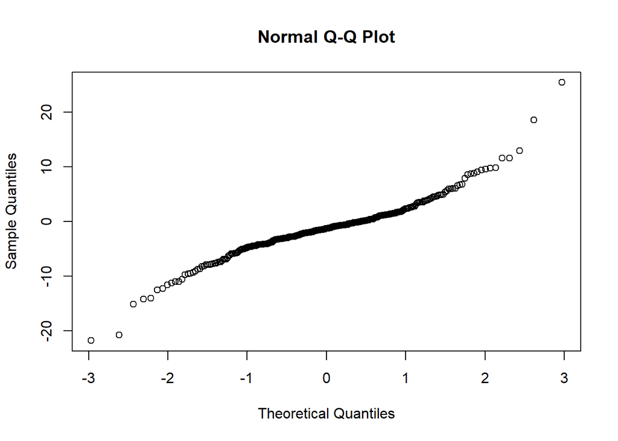

```r
qqnorm(inputDf$Trend)
```

```r
shapiro.test(inputDf$Trend)
```

```
##
##  Shapiro-Wilk normality test
##
## data:  inputDf$Trend
## W = 0.93649, p-value = 8.942e-11
```

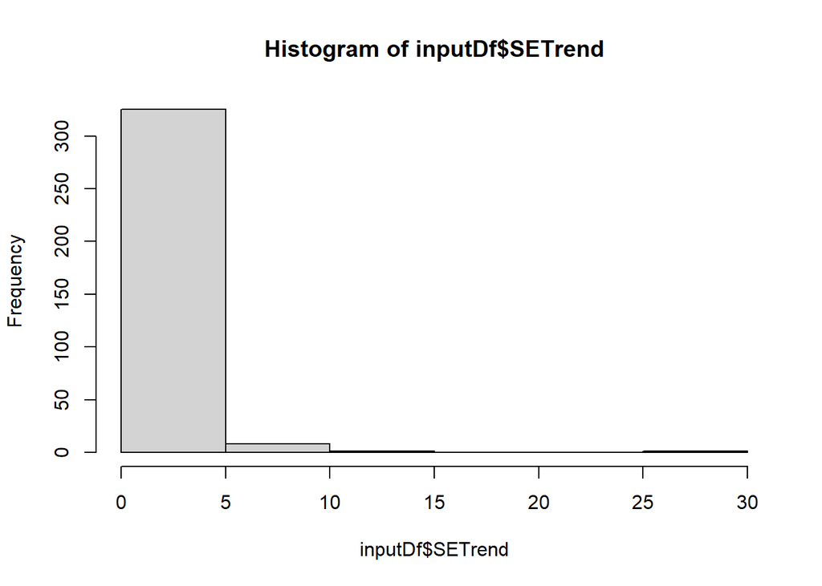

```r
#  Error estandard

hist(inputDf$SETrend)
```

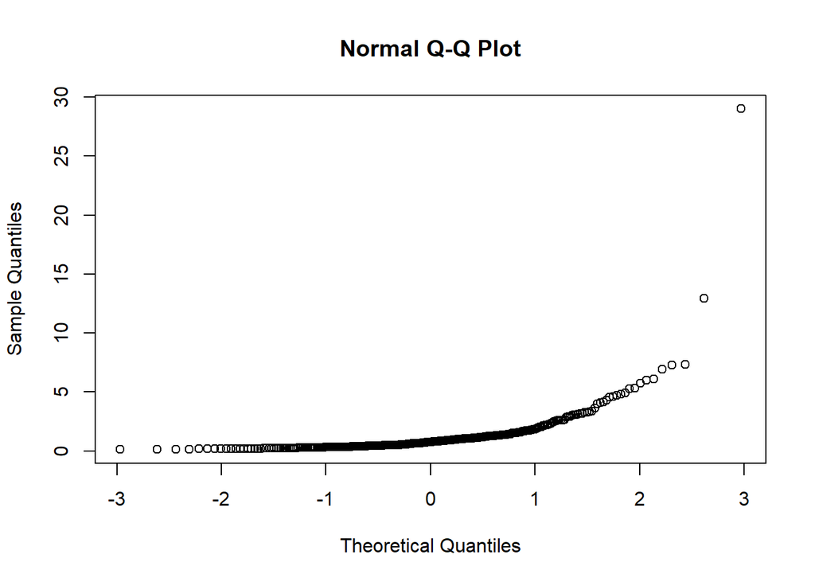

```r
qqnorm(inputDf$SETrend)
```

```r
shapiro.test(inputDf$SETrend)
```

```
##
##  Shapiro-Wilk normality test
##
## data:  inputDf$SETrend
## W = 0.4241, p-value < 2.2e-16
```

Aquí, ja hi ha més problemes, pel que optem per una tranformació logarítmica

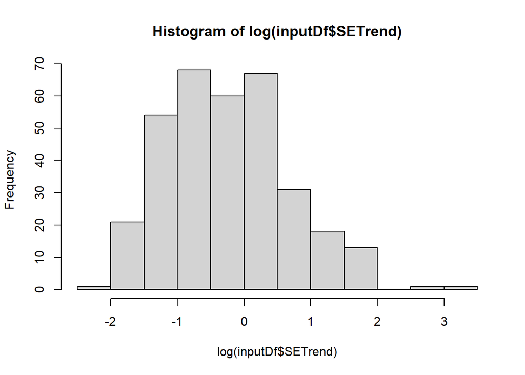

```r
hist(log(inputDf$SETrend))
```

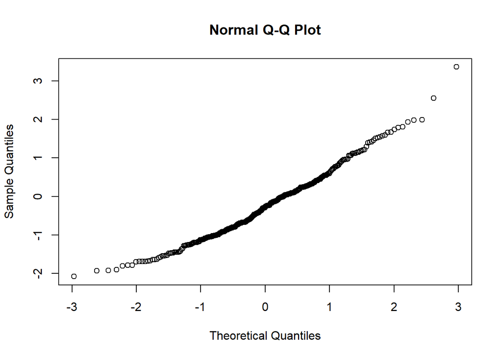

```r
qqnorm(log(inputDf$SETrend))
```

```r
shapiro.test(log(inputDf$SETrend))
```

```
##
##  Shapiro-Wilk normality test
##
## data:  log(inputDf$SETrend)
## W = 0.97946, p-value = 0.0001018
```

Això ja va millor i, per tant, treballarem amb el logaritme

# 4.1. Avaluació de la tendència en funció de la distribució i la cobertura del mostratge

Fem un gràfic primer per veure com s’ajunta la distribució a la tendència per taxon

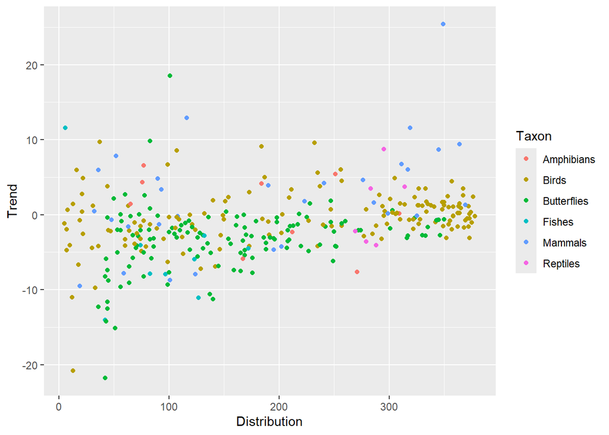

```r
ggplot(inputDf, aes(Distribution, Trend, color= Taxon) ) +
  geom_point() +
  labs(colour="Taxon")
```

I ara, separant cada tàxon

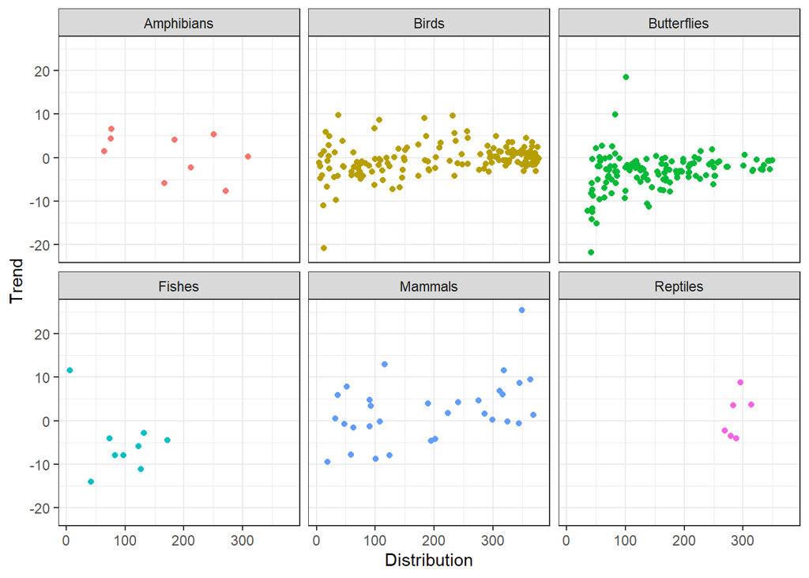

```r
ggplot(data = inputDf, aes(x = Distribution, y = Trend, color = Taxon)) +
  geom_point() +
  theme_bw() +
  facet_wrap(~ Taxon) + labs(y = "Trend") +
  theme(legend.position = "none")
```

Apunta coses

Fem, per tant models amb la tendència i la distribució, però mirem també si la cobertura hi té algun efecte. Comencem pel model simple només amb l’efecte aleatori per veure si a l’afegir més variables, els models expliquen més variació.

```r
DistModel0 <- lmer(Trend ~ (1 | Taxon),
     data = inputDf, weights = 1/SETrend)
summary(DistModel0)
```

```
## Linear mixed model fit by REML. t-tests use Satterthwaite's method [
## lmerModLmerTest]
## Formula: Trend ~ (1 | Taxon)
##    Data: inputDf
## Weights: 1/SETrend
##
## REML criterion at convergence: 1787.6
##
## Scaled residuals:
##     Min      1Q  Median      3Q     Max
## -3.4135 -0.6367 -0.0450  0.5671  3.8807
##
## Random effects:
##  Groups   Name        Variance Std.Dev.
##  Taxon    (Intercept)  6.881   2.623
##  Residual             14.952   3.867
## Number of obs: 335, groups:  Taxon, 6
##
## Fixed effects:
##             Estimate Std. Error     df t value Pr(>|t|)
## (Intercept)   -1.069      1.196  4.629  -0.893    0.416
```

```r
DistModel1 <- lmer(Trend ~ Distribution + (1 | Taxon),
     data = inputDf, weights = 1/SETrend)
summary(DistModel1)
```

```
## Linear mixed model fit by REML. t-tests use Satterthwaite's method [
## lmerModLmerTest]
## Formula: Trend ~ Distribution + (1 | Taxon)
##    Data: inputDf
## Weights: 1/SETrend
##
## REML criterion at convergence: 1769.4
##
## Scaled residuals:
##     Min      1Q  Median      3Q     Max
## -2.8467 -0.5642  0.0429  0.6261  3.8971
##
## Random effects:
##  Groups   Name        Variance Std.Dev.
##  Taxon    (Intercept)  4.97    2.229
##  Residual             13.77    3.711
## Number of obs: 335, groups:  Taxon, 6
##
## Fixed effects:
##                Estimate Std. Error         df t value Pr(>|t|)
## (Intercept)   -2.811424   1.084478   5.476046  -2.592   0.0447 *
## Distribution   0.007983   0.001439 331.292092   5.546 5.97e-08 ***
## ---
## Signif. codes:  0 '***' 0.001 '**' 0.01 '*' 0.05 '.' 0.1 ' ' 1
##
## Correlation of Fixed Effects:
##             (Intr)
## Distributin -0.290
```

I, ara, afegim la cobertura

```r
DistModel2 <- lmer(Trend ~ Distribution + SamplingCoverage + (1 | Taxon),
                   data = inputDf, weights = 1/SETrend)
summary(DistModel2)
```

```
## Linear mixed model fit by REML. t-tests use Satterthwaite's method [
## lmerModLmerTest]
## Formula: Trend ~ Distribution + SamplingCoverage + (1 | Taxon)
##    Data: inputDf
## Weights: 1/SETrend
##
## REML criterion at convergence: 1776.3
##
## Scaled residuals:
##     Min      1Q  Median      3Q     Max
## -2.8650 -0.5630  0.0401  0.6237  3.8844
##
## Random effects:
##  Groups   Name        Variance Std.Dev.
##  Taxon    (Intercept)  5.155   2.270
##  Residual             13.806   3.716
## Number of obs: 335, groups:  Taxon, 6
##
## Fixed effects:
##                    Estimate Std. Error         df t value Pr(>|t|)
## (Intercept)       -2.869363   1.157215   6.661300  -2.480   0.0439 *
## Distribution       0.007884   0.001551 331.999126   5.083 6.23e-07 ***
## SamplingCoverage   0.002058   0.012503 305.632642   0.165   0.8694
## ---
## Signif. codes:  0 '***' 0.001 '**' 0.01 '*' 0.05 '.' 0.1 ' ' 1
##
## Correlation of Fixed Effects:
##             (Intr) Dstrbt
## Distributin -0.138
## SamplngCvrg -0.311 -0.370
```

I provem també la interacció entre les dues variables

```r
DistModel3 <- lmer(Trend ~ Distribution * SamplingCoverage + (1 | Taxon),
                   data = inputDf, weights = 1/SETrend)
summary(DistModel3)
```

```
## Linear mixed model fit by REML. t-tests use Satterthwaite's method [
## lmerModLmerTest]
## Formula: Trend ~ Distribution * SamplingCoverage + (1 | Taxon)
##    Data: inputDf
## Weights: 1/SETrend
##
## REML criterion at convergence: 1790.4
##
## Scaled residuals:
##     Min      1Q  Median      3Q     Max
## -3.1623 -0.5906  0.0088  0.6636  3.8844
##
## Random effects:
##  Groups   Name        Variance Std.Dev.
##  Taxon    (Intercept)  5.201   2.281
##  Residual             13.725   3.705
## Number of obs: 335, groups:  Taxon, 6
##
## Fixed effects:
##                                 Estimate Std. Error         df t value Pr(>|t|)
## (Intercept)                   -4.498e+00  1.501e+00  1.788e+01  -2.996 0.007788
## Distribution                   1.528e-02  4.601e-03  3.307e+02   3.321 0.000997
## SamplingCoverage               3.182e-02  2.141e-02  3.307e+02   1.486 0.138177
## Distribution:SamplingCoverage -1.355e-04  7.936e-05  3.301e+02  -1.708 0.088652
##
## (Intercept)                   **
## Distribution                  ***
## SamplingCoverage
## Distribution:SamplingCoverage .
## ---
## Signif. codes:  0 '***' 0.001 '**' 0.01 '*' 0.05 '.' 0.1 ' ' 1
##
## Correlation of Fixed Effects:
##             (Intr) Dstrbt SmplnC
## Distributin -0.634
## SamplngCvrg -0.655  0.693
## Dstrbtn:SmC  0.635 -0.942 -0.813
## fit warnings:
## Some predictor variables are on very different scales: consider rescaling
```

A priori, sembla que el segon model, només amb distribució, és el que millor s’jausta i que, per tant, la cobertura del mostratge no té cap efecte sobre la tendència, però fem un test per assegurar que no val la pena, afegir complexitat al model.

```r
anova(DistModel0, DistModel1, DistModel2, DistModel3)
```

```
## refitting model(s) with ML (instead of REML)
```

```
## Data: inputDf
## Models:
## DistModel0: Trend ~ (1 | Taxon)
## DistModel1: Trend ~ Distribution + (1 | Taxon)
## DistModel2: Trend ~ Distribution + SamplingCoverage + (1 | Taxon)
## DistModel3: Trend ~ Distribution * SamplingCoverage + (1 | Taxon)
##            npar    AIC    BIC  logLik -2*log(L)   Chisq Df Pr(>Chisq)
## DistModel0    3 1795.7 1807.1 -894.82    1789.7
## DistModel1    4 1768.0 1783.2 -879.97    1760.0 29.7014  1   5.04e-08 ***
## DistModel2    5 1769.9 1789.0 -879.97    1759.9  0.0098  1    0.92101
## DistModel3    6 1769.0 1791.9 -878.51    1757.0  2.9214  1    0.08741 .
## ---
## Signif. codes:  0 '***' 0.001 '**' 0.01 '*' 0.05 '.' 0.1 ' ' 1
```

Per tant, sembla que els models més complexes no aporten més informació i ens quedem amb el model que incorpora només la distribució.

Per assegurar el tir, però, fem una validació del model amb qqplot i gràfics de residus vs prediccions

```r
# simulem els residus
SimResDistModel <- simulateResiduals(DistModel1)
```

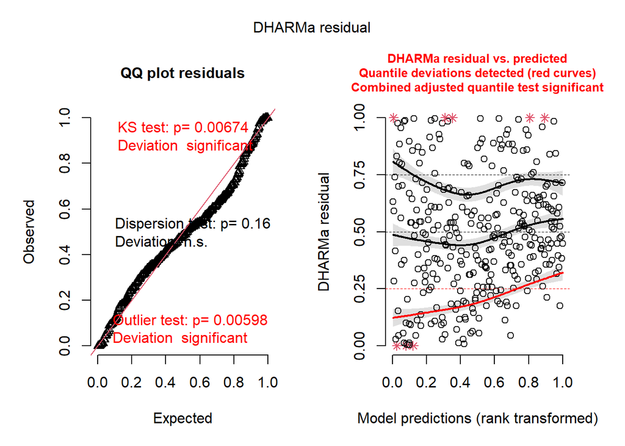

```r
plot(SimResDistModel)
```

De cara a fer sortides elegants, fem un gràfic per veure el model amb cada tàxon

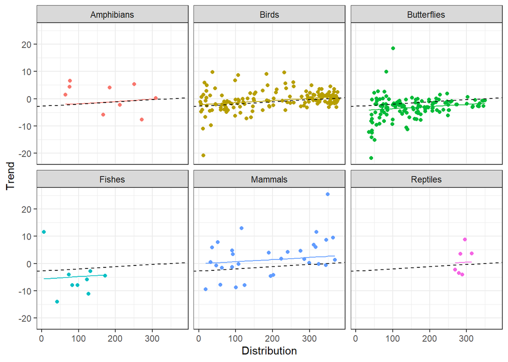

```r
inputDf$predictions <- predict(DistModel1)
coefs <- fixef(DistModel1)               # efectes fixos (intercept i pendent)

ggplot(data = inputDf, aes(x = Distribution, y = predictions, color = Taxon)) +
  geom_line() +
  geom_point(aes(x = Distribution, y = Trend, color = Taxon)) +
  geom_abline(intercept = coefs[1], slope = coefs[2], color = "black",
              linetype = "dashed", linewidth = 0.5) +
  theme_bw() +
  facet_wrap(~ Taxon) +
  theme(legend.position = "none") + labs(y = "Trend")
```

I un altre per veure el model amb els seus ICs

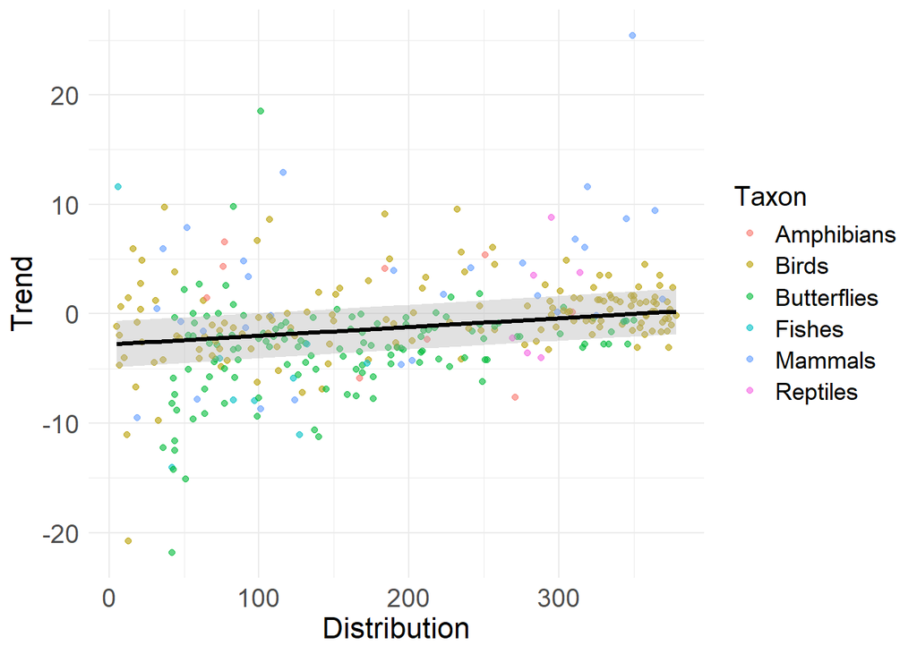

```r
# fem la matriu de var-cov dels efectes fixos
vcov_mat <- vcov(DistModel1)

# I un dataset per fer prediccions
new_data <- data.frame(
  Distribution = seq(min(inputDf$Distribution),
                     max(inputDf$Distribution),
                     length.out = 100)
)

# Matriu de disseny per a cada punt (1 columna d'intercept i 1 de la variable)
X <- model.matrix(~ Distribution, new_data)

# Prediccions (només efectes fixos)
new_data$fit <- X %*% coefs

# Error estàndard de la predicció
pred_var <- diag(X %*% vcov_mat %*% t(X))
new_data$se <- sqrt(pred_var)

# Interval de confiança del 95%
new_data$lwr <- new_data$fit - 1.96 * new_data$se
new_data$upr <- new_data$fit + 1.96 * new_data$se

# I ara, ho grafiquem tot
ggplot(inputDf, aes(Distribution, Trend, color = Taxon)) +
  geom_point(alpha = 0.6) +
  # Banda de confiança del model mixt
  geom_ribbon(
    data = new_data,
    aes(x = Distribution, ymin = lwr, ymax = upr),
    inherit.aes = FALSE,
    fill = "grey70", alpha = 0.4
  ) +
  # Recta global dels efectes fixos
  geom_line(
    data = new_data,
    aes(x = Distribution, y = fit),
    inherit.aes = FALSE,
    color = "black",
    linewidth = 1.2
  ) +
  labs(colour = "Taxon") +
  theme_minimal()  +
  theme(
    axis.title = element_text(size = 16),    # Títols dels eixos
    axis.text = element_text(size = 14),     # Nombres de marques
    legend.title = element_text(size = 15),  # Títol llegenda
    legend.text = element_text(size = 13)    # Text llegenda
  )
```

Un punt que no és trivial, és que ara tenim una relació entre la tendència i la la distribució, però entre una tendència extrema i la distribució que era el que buscavem. Ens va be tenir aquest primer resultat, però mirem el punt dels extrems de la tendència que ho farem de la mateixa manera, però amb el valor absolut de la tendència.

Seguim el mateix proces que abans, primer amb un test de normalitat

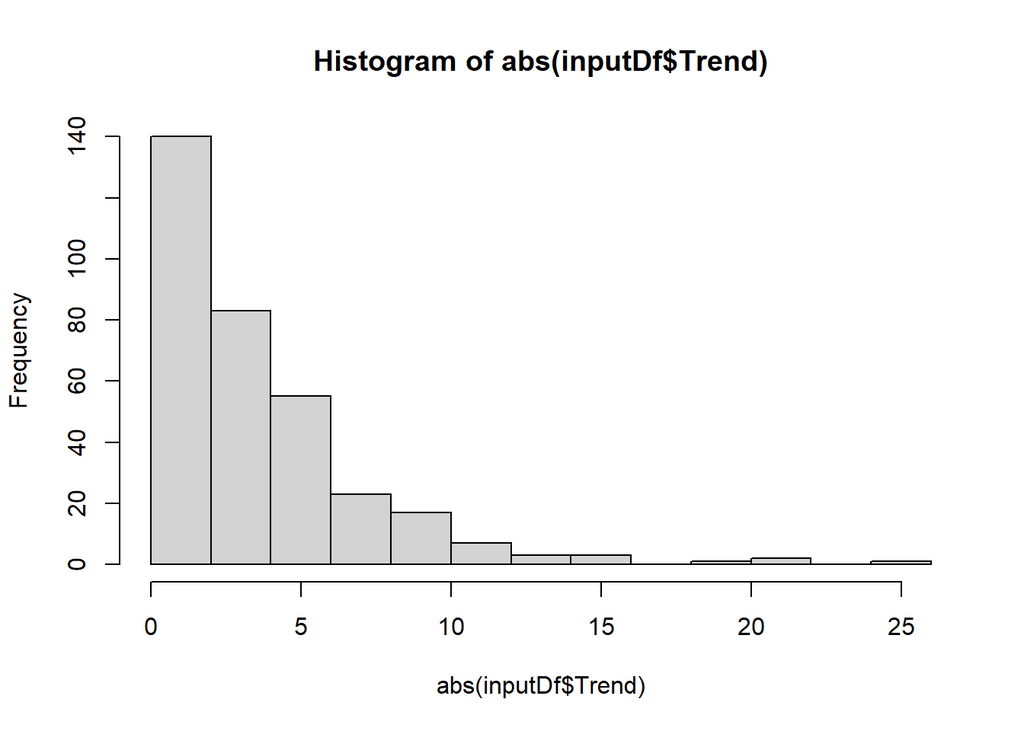

```r
#  Per la tendència

hist(abs(inputDf$Trend))
```

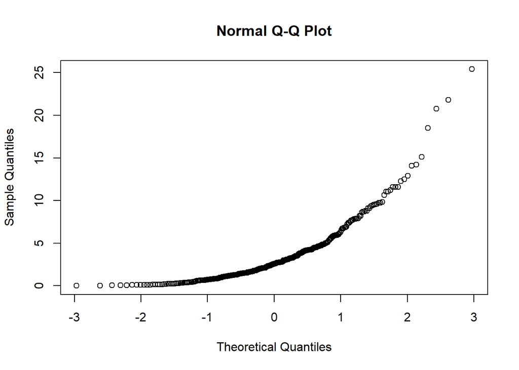

```r
qqnorm(abs(inputDf$Trend))
```

```r
shapiro.test(abs(inputDf$Trend))
```

```
##
##  Shapiro-Wilk normality test
##
## data:  abs(inputDf$Trend)
## W = 0.79194, p-value < 2.2e-16
```

Això ens suggereix provar amb una transformació logarítmica

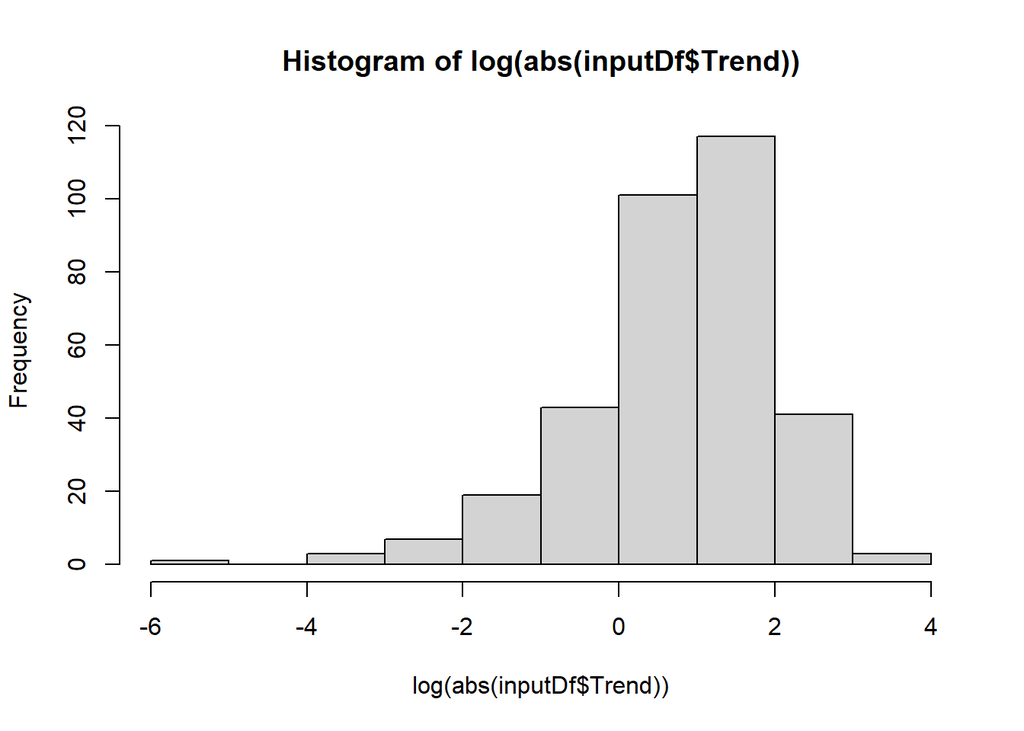

```r
#  Per la tendència

hist(log(abs(inputDf$Trend)))
```

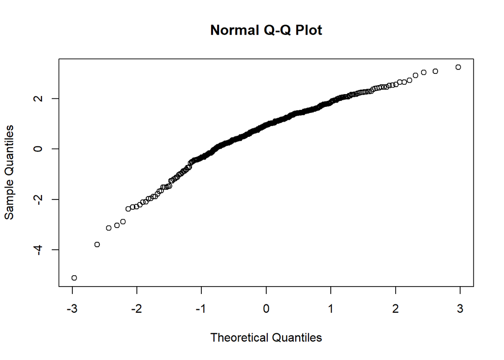

```r
qqnorm(log(abs(inputDf$Trend)))
```

```r
shapiro.test(log(abs(inputDf$Trend)))
```

```
##
##  Shapiro-Wilk normality test
##
## data:  log(abs(inputDf$Trend))
## W = 0.94358, p-value = 5.33e-10
```

Aqui sembla que millora, tot i algun valor una mica extrem

I, després, amb dos gràfics preliminars

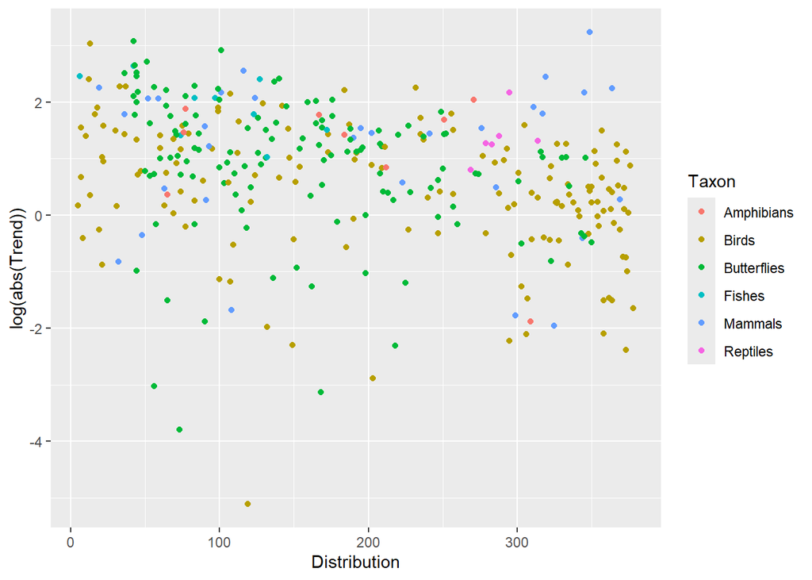

```r
ggplot(inputDf, aes(Distribution, log(abs(Trend)), color= Taxon) ) +
  geom_point() +
  labs(colour="Taxon")
```

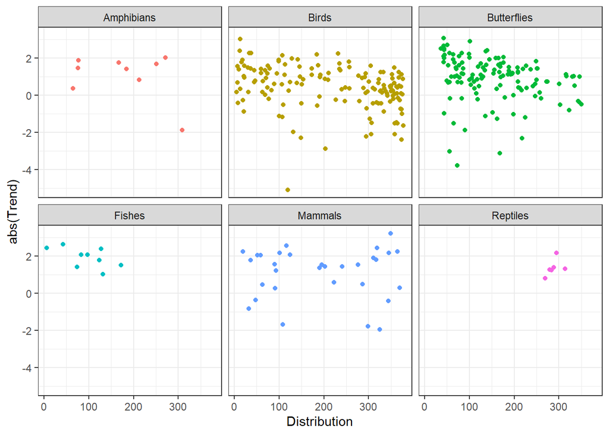

```r
ggplot(data = inputDf, aes(x = Distribution, y = log(abs(Trend)), color = Taxon)) +
  geom_point() +
  theme_bw() +
  facet_wrap(~ Taxon) + labs(y = "abs(Trend)") +
  theme(legend.position = "none")
```

Aparentment, funciona. Fem els models.

```r
DistAbsModel0 <- lmer(log(abs(Trend)) ~ (1 | Taxon),
                   data = inputDf, weights = 1/SETrend)
summary(DistAbsModel0)
```

```
## Linear mixed model fit by REML. t-tests use Satterthwaite's method [
## lmerModLmerTest]
## Formula: log(abs(Trend)) ~ (1 | Taxon)
##    Data: inputDf
## Weights: 1/SETrend
##
## REML criterion at convergence: 1114
##
## Scaled residuals:
##     Min      1Q  Median      3Q     Max
## -4.6016 -0.2435  0.3101  0.6979  2.0411
##
## Random effects:
##  Groups   Name        Variance Std.Dev.
##  Taxon    (Intercept) 0.215    0.4637
##  Residual             2.020    1.4212
## Number of obs: 335, groups:  Taxon, 6
##
## Fixed effects:
##             Estimate Std. Error     df t value Pr(>|t|)
## (Intercept)   0.7862     0.2465 3.7735    3.19   0.0361 *
## ---
## Signif. codes:  0 '***' 0.001 '**' 0.01 '*' 0.05 '.' 0.1 ' ' 1
```

```r
DistAbsModel1 <- lmer(log(abs(Trend)) ~ Distribution + (1 | Taxon),
                   data = inputDf, weights = 1/SETrend)
summary(DistAbsModel1)
```

```
## Linear mixed model fit by REML. t-tests use Satterthwaite's method [
## lmerModLmerTest]
## Formula: log(abs(Trend)) ~ Distribution + (1 | Taxon)
##    Data: inputDf
## Weights: 1/SETrend
##
## REML criterion at convergence: 1102.8
##
## Scaled residuals:
##     Min      1Q  Median      3Q     Max
## -4.2711 -0.3318  0.2736  0.6906  2.3468
##
## Random effects:
##  Groups   Name        Variance Std.Dev.
##  Taxon    (Intercept) 0.1195   0.3457
##  Residual             1.8905   1.3750
## Number of obs: 335, groups:  Taxon, 6
##
## Fixed effects:
##                Estimate Std. Error         df t value Pr(>|t|)
## (Intercept)   1.332e+00  2.300e-01  5.788e+00   5.789  0.00132 **
## Distribution -2.682e-03  5.301e-04  3.325e+02  -5.059 6.98e-07 ***
## ---
## Signif. codes:  0 '***' 0.001 '**' 0.01 '*' 0.05 '.' 0.1 ' ' 1
##
## Correlation of Fixed Effects:
##             (Intr)
## Distributin -0.520
```

```r
DistAbsModel2 <- lmer(log(abs(Trend)) ~ Distribution + SamplingCoverage + (1 | Taxon),
                   data = inputDf, weights = 1/SETrend)
summary(DistAbsModel2)
```

```
## Linear mixed model fit by REML. t-tests use Satterthwaite's method [
## lmerModLmerTest]
## Formula: log(abs(Trend)) ~ Distribution + SamplingCoverage + (1 | Taxon)
##    Data: inputDf
## Weights: 1/SETrend
##
## REML criterion at convergence: 1110.4
##
## Scaled residuals:
##     Min      1Q  Median      3Q     Max
## -4.1616 -0.3240  0.2708  0.6421  2.4297
##
## Random effects:
##  Groups   Name        Variance Std.Dev.
##  Taxon    (Intercept) 0.07361  0.2713
##  Residual             1.89391  1.3762
## Number of obs: 335, groups:  Taxon, 6
##
## Fixed effects:
##                    Estimate Std. Error         df t value Pr(>|t|)
## (Intercept)       1.481e+00  2.532e-01  1.209e+01   5.851 7.61e-05 ***
## Distribution     -2.454e-03  5.669e-04  3.299e+02  -4.329 1.99e-05 ***
## SamplingCoverage -5.555e-03  4.343e-03  1.235e+02  -1.279    0.203
## ---
## Signif. codes:  0 '***' 0.001 '**' 0.01 '*' 0.05 '.' 0.1 ' ' 1
##
## Correlation of Fixed Effects:
##             (Intr) Dstrbt
## Distributin -0.234
## SamplngCvrg -0.590 -0.359
```

```r
DistAbsModel3 <- lmer(log(abs(Trend)) ~ Distribution * SamplingCoverage + (1 | Taxon),
                   data = inputDf, weights = 1/SETrend)
summary(DistAbsModel3)
```

```
## Linear mixed model fit by REML. t-tests use Satterthwaite's method [
## lmerModLmerTest]
## Formula: log(abs(Trend)) ~ Distribution * SamplingCoverage + (1 | Taxon)
##    Data: inputDf
## Weights: 1/SETrend
##
## REML criterion at convergence: 1128.9
##
## Scaled residuals:
##     Min      1Q  Median      3Q     Max
## -4.0780 -0.3263  0.2678  0.6264  2.4758
##
## Random effects:
##  Groups   Name        Variance Std.Dev.
##  Taxon    (Intercept) 0.06142  0.2478
##  Residual             1.89886  1.3780
## Number of obs: 335, groups:  Taxon, 6
##
## Fixed effects:
##                                 Estimate Std. Error         df t value Pr(>|t|)
## (Intercept)                    1.236e+00  4.246e-01  7.844e+01   2.911  0.00469
## Distribution                  -1.345e-03  1.692e-03  3.286e+02  -0.795  0.42741
## SamplingCoverage              -1.201e-03  7.862e-03  3.283e+02  -0.153  0.87873
## Distribution:SamplingCoverage -2.037e-05  2.923e-05  3.277e+02  -0.697  0.48640
##
## (Intercept)                   **
## Distribution
## SamplingCoverage
## Distribution:SamplingCoverage
## ---
## Signif. codes:  0 '***' 0.001 '**' 0.01 '*' 0.05 '.' 0.1 ' ' 1
##
## Correlation of Fixed Effects:
##             (Intr) Dstrbt SmplnC
## Distributin -0.813
## SamplngCvrg -0.874  0.721
## Dstrbtn:SmC  0.813 -0.942 -0.836
## fit warnings:
## Some predictor variables are on very different scales: consider rescaling
```

I els comparem

```r
anova(DistAbsModel0, DistAbsModel1, DistAbsModel2, DistAbsModel3)
```

```
## refitting model(s) with ML (instead of REML)
```

```
## Data: inputDf
## Models:
## DistAbsModel0: log(abs(Trend)) ~ (1 | Taxon)
## DistAbsModel1: log(abs(Trend)) ~ Distribution + (1 | Taxon)
## DistAbsModel2: log(abs(Trend)) ~ Distribution + SamplingCoverage + (1 | Taxon)
## DistAbsModel3: log(abs(Trend)) ~ Distribution * SamplingCoverage + (1 | Taxon)
##               npar    AIC    BIC  logLik -2*log(L)   Chisq Df Pr(>Chisq)
## DistAbsModel0    3 1118.9 1130.3 -556.45    1112.9
## DistAbsModel1    4 1096.0 1111.2 -543.97    1088.0 24.9429  1  5.905e-07 ***
## DistAbsModel2    5 1095.9 1115.0 -542.95    1085.9  2.0461  1     0.1526
## DistAbsModel3    6 1097.2 1120.0 -542.58    1085.2  0.7423  1     0.3889
## ---
## Signif. codes:  0 '***' 0.001 '**' 0.01 '*' 0.05 '.' 0.1 ' ' 1
```

Novament sembla que el model més complex no aporta res i que el factor aleatori explica una part de la variació.

Validem el model amb distribució

```r
# simulem els residus
SimResDistAbsModel <- simulateResiduals(DistAbsModel1)
```

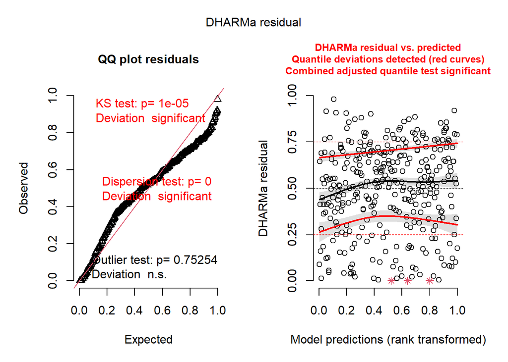

```r
plot(SimResDistAbsModel)
```

Sembla que el model peca d’heterocedasticitat, però novamemt cal considerar el tipus de dada que tractem i que no hi ha presència d’outliers.

Per tant, ens quedarem amb el model senzill que ens indica que la tendència és més extrema en aquelles espècies amb una menor distribució el que vol dir que aquestes tendències influiran més en l’LPI-cat. D’altra banda, sembla que aquests models s’ajusten millor que els de la tendència el que, potser apunta que la relació és més forta amb el valor absolut, és a dir amb tendències extremes que amb negatives.

Fem les sortides pel TFM

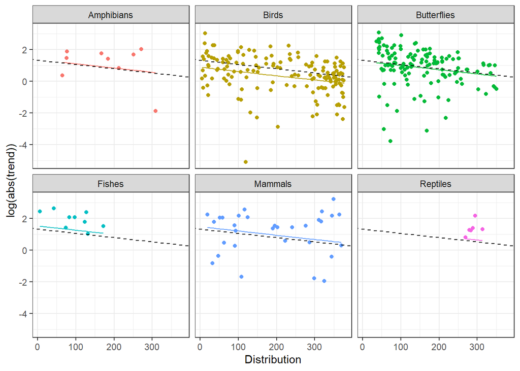

```r
#   Gràfic on es veu cada model i el model general

inputDf$predictions2 <- predict(DistAbsModel1)

coefs_abs <- fixef(DistAbsModel1)               # efectes fixos (intercept i pendent)

ggplot(data = inputDf, aes(x = Distribution, y = predictions2, color = Taxon)) +
  geom_line() +
  geom_point(aes(x = Distribution, y = log(abs(Trend)), color = Taxon)) +
  geom_abline(intercept = coefs_abs[1], slope = coefs_abs[2], color = "black",
              linetype = "dashed", linewidth = 0.5) +
  theme_bw() +
  facet_wrap(~ Taxon) +
  theme(legend.position = "none") + labs(y = "log(abs(trend))")
```

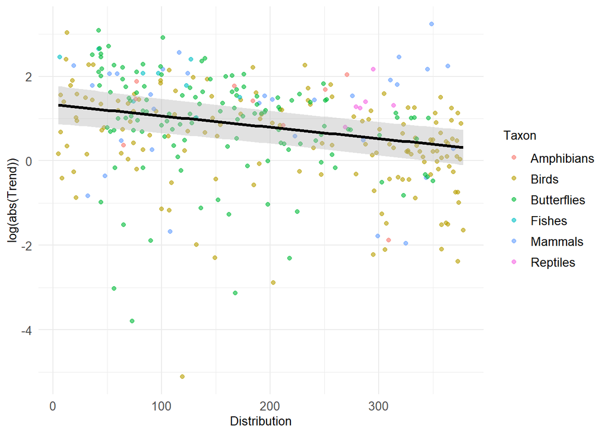

```r
# I un segon gràfic amb les dades crues, el model i els seus IC

# matriu de var-cov dels efectes fixos
vcov_mat_abs <- vcov(DistAbsModel1)

new_data_abs <- data.frame(
  Distribution = seq(min(inputDf$Distribution),
                     max(inputDf$Distribution),
                     length.out = 100)
)
# Matriu de disseny per a cada punt (1 columna d'intercept i 1 de la variable)
X_abs <- model.matrix(~ Distribution, new_data_abs)

# Prediccions (només efectes fixos)
new_data_abs$fit <- X_abs %*% coefs_abs

# Error estàndard de la predicció
pred_var_abs <- diag(X_abs %*% vcov_mat_abs %*% t(X_abs))
new_data_abs$se <- sqrt(pred_var_abs)

# Interval de confiança del 95%
new_data_abs$lwr <- new_data_abs$fit - 1.96 * new_data_abs$se
new_data_abs$upr <- new_data_abs$fit + 1.96 * new_data_abs$se

ggplot(inputDf, aes(Distribution, log(abs(Trend)), color = Taxon)) +
  geom_point(alpha = 0.6) +
  # Banda de confiança del model mixt
  geom_ribbon(
    data = new_data_abs,
    aes(x = Distribution, ymin = lwr, ymax = upr),
    inherit.aes = FALSE,
    fill = "grey70", alpha = 0.4
  ) +
  # Recta global dels efectes fixos
  geom_line(
    data = new_data_abs,
    aes(x = Distribution, y = fit),
    inherit.aes = FALSE,
    color = "black",
    linewidth = 1.2
  ) +
  labs(colour = "Taxon") +
  theme_minimal()  +
  theme(
    axis.title = element_text(size = 10),    # Títols dels eixos
    axis.text = element_text(size = 10),     # Nombres de marques
    legend.title = element_text(size = 10),  # Títol llegenda
    legend.text = element_text(size = 10)    # Text llegenda
  )
```

## 4.2. Avaluació de l’error estàndard de la tendència en funció de la cobertura del mostratge i la distribució de l’espècie

Farem el mateix procés que abans, però utilitzant el logaritme de l’error estàndard, en comptes de l’error tal qual.

Comencem pels gràfics previs

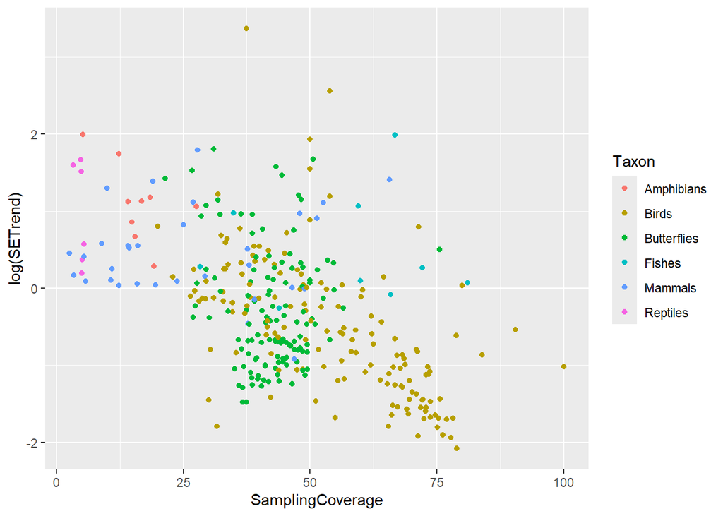

```r
ggplot(inputDf, aes(SamplingCoverage, log(SETrend), color= Taxon) ) +
  geom_point() +
  labs(colour="Taxon")
```

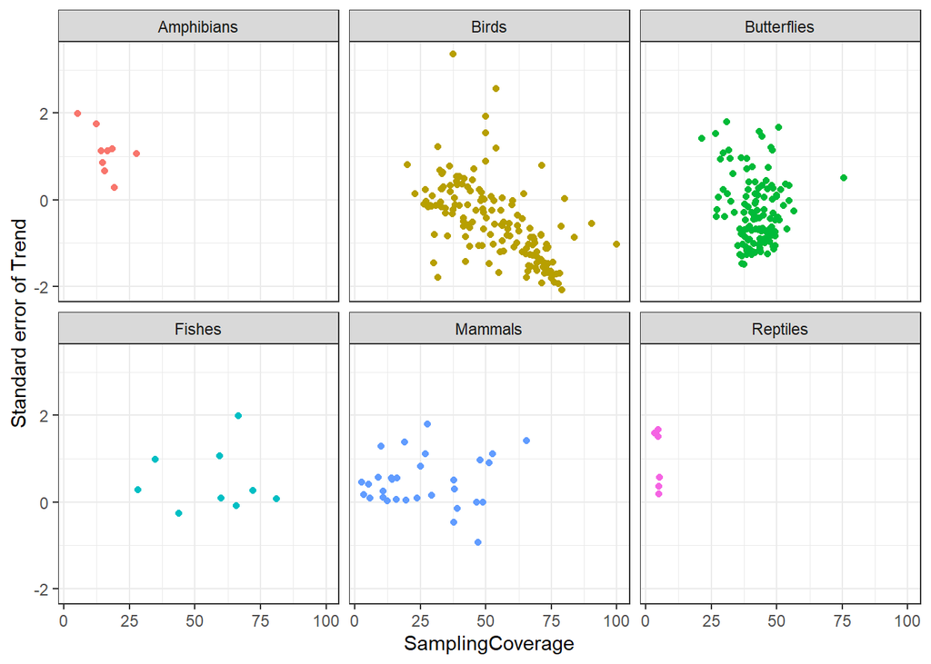

```r
ggplot(data = inputDf, aes(x = SamplingCoverage, y = log(SETrend), color = Taxon)) +
  geom_point() +
  theme_bw() +
  facet_wrap(~ Taxon) + labs(y = "Standard error of Trend") +
  theme(legend.position = "none")
```

Sembla que alguna relació hi ha. Per tant, anem pels models per testar la incertesa de la tendència. Fem un de simple amb la cobertura, i un segon afegint la distribució.

```r
SampleModel0 <- lmer(log(SETrend) ~ (1 | Taxon),
                   data = inputDf)
summary(SampleModel0)
```

```
## Linear mixed model fit by REML. t-tests use Satterthwaite's method [
## lmerModLmerTest]
## Formula: log(SETrend) ~ (1 | Taxon)
##    Data: inputDf
##
## REML criterion at convergence: 826.6
##
## Scaled residuals:
##     Min      1Q  Median      3Q     Max
## -1.9348 -0.7018 -0.1312  0.6367  4.7924
##
## Random effects:
##  Groups   Name        Variance Std.Dev.
##  Taxon    (Intercept) 0.4037   0.6354
##  Residual             0.6564   0.8102
## Number of obs: 335, groups:  Taxon, 6
##
## Fixed effects:
##             Estimate Std. Error     df t value Pr(>|t|)
## (Intercept)   0.3273     0.2732 5.0718   1.198    0.284
```

```r
SampleModel1 <- lmer(log(SETrend) ~ SamplingCoverage + (1 | Taxon),
                   data = inputDf)
summary(SampleModel1)
```

```
## Linear mixed model fit by REML. t-tests use Satterthwaite's method [
## lmerModLmerTest]
## Formula: log(SETrend) ~ SamplingCoverage + (1 | Taxon)
##    Data: inputDf
##
## REML criterion at convergence: 780.1
##
## Scaled residuals:
##     Min      1Q  Median      3Q     Max
## -2.4040 -0.7410 -0.1723  0.5907  4.6609
##
## Random effects:
##  Groups   Name        Variance Std.Dev.
##  Taxon    (Intercept) 0.1526   0.3907
##  Residual             0.5621   0.7497
## Number of obs: 335, groups:  Taxon, 6
##
## Fixed effects:
##                    Estimate Std. Error         df t value Pr(>|t|)
## (Intercept)        1.103981   0.204979   8.355416   5.386 0.000568 ***
## SamplingCoverage  -0.023341   0.002939 246.450523  -7.942 7.09e-14 ***
## ---
## Signif. codes:  0 '***' 0.001 '**' 0.01 '*' 0.05 '.' 0.1 ' ' 1
##
## Correlation of Fixed Effects:
##             (Intr)
## SamplngCvrg -0.506
```

```r
SampleModel2 <- lmer(log(SETrend) ~ SamplingCoverage + Distribution + (1 | Taxon),
                   data = inputDf)
summary(SampleModel2)
```

```
## Linear mixed model fit by REML. t-tests use Satterthwaite's method [
## lmerModLmerTest]
## Formula: log(SETrend) ~ SamplingCoverage + Distribution + (1 | Taxon)
##    Data: inputDf
##
## REML criterion at convergence: 599.1
##
## Scaled residuals:
##     Min      1Q  Median      3Q     Max
## -4.5168 -0.5837 -0.1447  0.4811  4.8853
##
## Random effects:
##  Groups   Name        Variance Std.Dev.
##  Taxon    (Intercept) 0.2588   0.5087
##  Residual             0.3089   0.5558
## Number of obs: 335, groups:  Taxon, 6
##
## Fixed effects:
##                    Estimate Std. Error         df t value Pr(>|t|)
## (Intercept)       1.689e+00  2.317e-01  6.163e+00   7.292    3e-04 ***
## SamplingCoverage -1.369e-02  2.316e-03  3.117e+02  -5.911 8.94e-09 ***
## Distribution     -4.733e-03  2.889e-04  3.319e+02 -16.382  < 2e-16 ***
## ---
## Signif. codes:  0 '***' 0.001 '**' 0.01 '*' 0.05 '.' 0.1 ' ' 1
##
## Correlation of Fixed Effects:
##             (Intr) SmplnC
## SamplngCvrg -0.283
## Distributin -0.148 -0.250
```

```r
SampleModel3 <- lmer(log(SETrend) ~ SamplingCoverage * Distribution + (1 | Taxon),
                   data = inputDf)
summary(SampleModel3)
```

```
## Linear mixed model fit by REML. t-tests use Satterthwaite's method [
## lmerModLmerTest]
## Formula: log(SETrend) ~ SamplingCoverage * Distribution + (1 | Taxon)
##    Data: inputDf
##
## REML criterion at convergence: 618.6
##
## Scaled residuals:
##     Min      1Q  Median      3Q     Max
## -4.4575 -0.5791 -0.1152  0.4744  4.9137
##
## Random effects:
##  Groups   Name        Variance Std.Dev.
##  Taxon    (Intercept) 0.2404   0.4903
##  Residual             0.3093   0.5562
## Number of obs: 335, groups:  Taxon, 6
##
## Fixed effects:
##                                 Estimate Std. Error         df t value Pr(>|t|)
## (Intercept)                    1.547e+00  2.721e-01  1.289e+01   5.685 7.74e-05
## SamplingCoverage              -1.109e-02  3.683e-03  3.308e+02  -3.010  0.00281
## Distribution                  -4.024e-03  8.128e-04  3.304e+02  -4.950 1.18e-06
## SamplingCoverage:Distribution -1.400e-05  1.505e-05  3.310e+02  -0.930  0.35296
##
## (Intercept)                   ***
## SamplingCoverage              **
## Distribution                  ***
## SamplingCoverage:Distribution
## ---
## Signif. codes:  0 '***' 0.001 '**' 0.01 '*' 0.05 '.' 0.1 ' ' 1
##
## Correlation of Fixed Effects:
##             (Intr) SmplnC Dstrbt
## SamplngCvrg -0.589
## Distributin -0.570  0.671
## SmplngCvr:D  0.562 -0.778 -0.935
## fit warnings:
## Some predictor variables are on very different scales: consider rescaling
```

Sembla que, aquest cop, si que les dues variables tenen una relació significativa amb l’error estàndard de la tendència, però fem el test per confirmar que el segon model val la pena

```r
anova(SampleModel0, SampleModel1, SampleModel2, SampleModel3)
```

```
## refitting model(s) with ML (instead of REML)
```

```
## Data: inputDf
## Models:
## SampleModel0: log(SETrend) ~ (1 | Taxon)
## SampleModel1: log(SETrend) ~ SamplingCoverage + (1 | Taxon)
## SampleModel2: log(SETrend) ~ SamplingCoverage + Distribution + (1 | Taxon)
## SampleModel3: log(SETrend) ~ SamplingCoverage * Distribution + (1 | Taxon)
##              npar    AIC    BIC  logLik -2*log(L)    Chisq Df Pr(>Chisq)
## SampleModel0    3 831.79 843.23 -412.89    825.79
## SampleModel1    4 776.58 791.83 -384.29    768.58  57.2085  1   3.92e-14 ***
## SampleModel2    5 582.93 602.00 -286.47    572.93 195.6449  1  < 2.2e-16 ***
## SampleModel3    6 584.00 606.88 -286.00    572.00   0.9352  1     0.3335
## ---
## Signif. codes:  0 '***' 0.001 '**' 0.01 '*' 0.05 '.' 0.1 ' ' 1
```

En aquest cas, sembla que el millor model és el que incorpora les dues variables semse interacció.

Validem el model amb les dues variables sense interacció

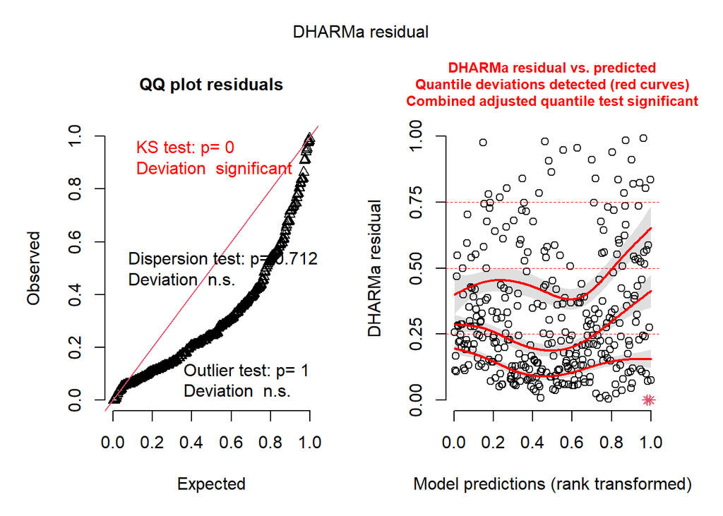

```r
SimResSampleModel <- simulateResiduals(SampleModel2)
plot(SimResSampleModel)
```

Novament els residus no s’ajusten molt a una normal, però no es detecten outliers i, considerant la tipologia de les dades, no cal patir

```
## Model has log-transformed response. Back-transforming predictions to
##   original response scale. Standard errors are still on the transformed
```

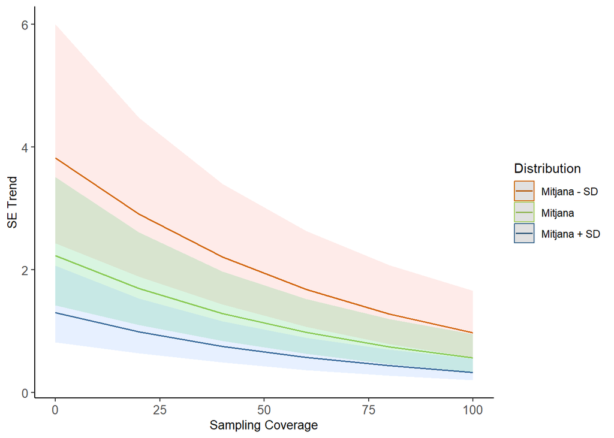

```r
plot_model(
  SampleModel2,
  type = "pred",
  terms = c("SamplingCoverage", "Distribution")
) +
  scale_color_manual(
    values = c("darkorange3", "darkolivegreen3", "steelblue4"),   # Colors per les línies
    labels = c("Mitjana - SD", "Mitjana", "Mitjana + SD")  # Labels a la llegenda
  ) +
  theme_classic() +
  theme(
    plot.title = element_blank(),
    axis.title = element_text(size = 10),
    axis.text  = element_text(size = 10)
  )
```

# 5. Valoració dels models escollits.

Un punt interessant també pot ser mirar la $R^2$ dels models. Ho fem amb el paquet MuMin que dona $R^2m$ que és la $R^2$ marginal, és a dir sense els efectes aleatoris i la $R^2$ condicional que incopora els efectes aleatoris.

```r
r.squaredGLMM(DistModel1)
```

```
##             R2m       R2c
## [1,] 0.04216783 0.2961875
```

```r
r.squaredGLMM(DistAbsModel1)
```

```
##             R2m       R2c
## [1,] 0.04427358 0.1011021
```

```r
r.squaredGLMM(SampleModel2)
```

```
##            R2m       R2c
## [1,] 0.4151928 0.6817751
```

# 6. Conclusions relatives a la relació entre les tendències, la distribució i la cobertura

1. La menor distribució s’associa a tendències més extremes i més negatives. El que vol dir que les especialistes són les més damnificades dels processos de canvi i les que poden influir més en el LPI.
2. Sembla que la cobertura no influeix en la tendència, ni per fer-la més o menys negativa, ni per fer-la més extrema. Per tant, potser una mala cobertura, no és un problema. Però no sabem si una major cobertura, pot canviar el signe d’una tendència.
3. Això no sembla canviar massa per taxons, però si que sembla que incorporar el tàxon com un efecte aleatori explica més la variabilitat dels models.
4. Menors cobertures i distribucions impliquen major incertesa. En el cas de la distribució, és igual, ja que no es pot resoldre. En el cas de la cobertura, sí que això implica que millor que sigui com més gran major.